# micro-RNA Heart Transplantation - Differential expression analysis

```r
knitr::opts_chunk$set(warning = FALSE, message = FALSE)
```

## Setup & Libraries

```r
library(ggplot2)
library(tidyverse)
library(DESeq2)
library(pheatmap)
library(RColorBrewer)
library(EnhancedVolcano)
library(vsn)
library(ggvenn)
library(patchwork)
library(ggplotify)
library(ggrepel)
```

## Data Import

**Importing Clinical Data**

```r
setwd("~/GitHub/ncRNA_heart_transplant")
coldata <- read_tsv("data/phenotable.txt", show_col_types = FALSE)

#coldata <- coldata %>%
#dplyr::filter(!sample %in% c(
#    "182_S25_R1_001"
#  ))
coldata
```

```
## # A tibble: 20 × 3
##    sample         condition antibody
##    <chr>          <chr>     <chr>
##  1 105_S1_R1_001  NR        no
##  2 166_S4_R1_001  ACR       no
##  3 144_S5_R1_001  CAV       no
##  4 135_S7_R1_001  CAV       no
##  5 128_S8_R1_001  NR        no
##  6 109_S9_R1_001  NR        no
##  7 187_S10_R1_001 NR        no
##  8 125_S11_R1_001 NR        yes
##  9 124_S16_R1_001 ACR       no
## 10 103_S17_R1_001 ACR       no
## 11 123_S20_R1_001 CAV       no
## 12 192_S22_R1_001 AMR       no
## 13 167_S23_R1_001 CAV       no
## 14 121_S24_R1_001 CAV       no
## 15 182_S25_R1_001 AMR       yes
## 16 179_S26_R1_001 AMR       no
## 17 112_S27_R1_001 NR        no
## 18 106_S28_R1_001 NR        yes
## 19 138_S30_R1_001 NR        no
## 20 127_S29_R1_001 AMR       yes
```

**Importing Raw Counts**

```r
counts <- read.csv("data/miRNA_raw_counts_all_samples.csv", header = TRUE, sep = ",")
counts <- column_to_rownames(counts, var = "X")
counts <- t(counts)
rownames(counts) <- gsub("\\.", "-", rownames(counts))
head(counts)
```

```
##                     105_S1_R1_001 166_S4_R1_001 144_S5_R1_001 135_S7_R1_001
## hsa-let-7a-2-3p                 0             0             0             0
## hsa-let-7a-3p                 151           289           132           257
## hsa-let-7a-5p-7c-5p         70803         61240         44676        127638
## hsa-let-7b-3p                 136           116           107           110
## hsa-let-7b-5p               16746         10461         13828         19229
## hsa-let-7c-3p                   0             0             0             0
##                     128_S8_R1_001 109_S9_R1_001 187_S10_R1_001 125_S11_R1_001
## hsa-let-7a-2-3p                 0             0              0              0
## hsa-let-7a-3p                 236           207            150            447
## hsa-let-7a-5p-7c-5p        142998        140091          73040         108998
## hsa-let-7b-3p                  57            76            201            152
## hsa-let-7b-5p               26730         21797          11771           8588
## hsa-let-7c-3p                   0             0              0              0
##                     124_S16_R1_001 103_S17_R1_001 123_S20_R1_001 192_S22_R1_001
## hsa-let-7a-2-3p                  0              0              0              0
## hsa-let-7a-3p                  213            200            273            264
## hsa-let-7a-5p-7c-5p          80045          60959          99114         140333
## hsa-let-7b-3p                  140            136            146            165
## hsa-let-7b-5p                18048          12270          31399          37892
## hsa-let-7c-3p                    0              0              5              0
##                     167_S23_R1_001 121_S24_R1_001 182_S25_R1_001 179_S26_R1_001
## hsa-let-7a-2-3p                  0              0              9              0
## hsa-let-7a-3p                   19             92           1679            398
## hsa-let-7a-5p-7c-5p          90917         143091          45963         105957
## hsa-let-7b-3p                   43             37           1212            230
## hsa-let-7b-5p                38677          53272          14348          19112
## hsa-let-7c-3p                    0              0             59              0
##                     112_S27_R1_001 106_S28_R1_001 138_S30_R1_001 127_S29_R1_001
## hsa-let-7a-2-3p                  0              0              0              0
## hsa-let-7a-3p                  202              5            691              0
## hsa-let-7a-5p-7c-5p          85168          17338          53985          13235
## hsa-let-7b-3p                  111              3            179              0
## hsa-let-7b-5p                34271           8843          16421           5866
## hsa-let-7c-3p                    0              0              0              0
```

**Importing Annotation Data:**

```r
anno <- read.csv("data/anno_report.csv", header = TRUE, sep = ",")
anno
```

```
##    Sample.name.s. Filtered.miRNA.Reads Hairpin.miRNAs mature.tRNA.Reads
## 1   105_S1_R1_001             16771254           1611             44435
## 2   166_S4_R1_001             25629332           1367            140585
## 3   144_S5_R1_001             23203639            530             38313
## 4   135_S7_R1_001             26188565           1172             35388
## 5   128_S8_R1_001             37265549           1304             44252
## 6   109_S9_R1_001             23665139            872             60970
## 7  187_S10_R1_001             16840522           1475            175725
## 8  125_S11_R1_001             21501577           2151             60585
## 9  124_S16_R1_001             30962515           1063             53091
## 10 103_S17_R1_001             26669389           1311             55217
## 11 123_S20_R1_001             28199537            787             74261
## 12 192_S22_R1_001             26591265           1336             69774
## 13 167_S23_R1_001             34709811           6782             83663
## 14 121_S24_R1_001             25977279            750             91450
```

[output cut: 27 more lines]

**Merging & Summarization**  
Calculating the sum of reads for each RNA type across every clinical condition (NR, ACR, AMR, CAV)

```r
merged_df <- left_join(anno, coldata, by = c("Sample.name.s." = "sample"))
summed_anno <- merged_df %>%
  filter(!is.na(condition)) %>%
  group_by(condition) %>%
  summarise(across(where(is.numeric), sum), .groups = "drop")

summed_anno
```

```
## # A tibble: 4 × 9
##   condition Filtered.miRNA.Reads Hairpin.miRNAs mature.tRNA.Reads
##   <chr>                    <int>          <int>             <int>
## 1 ACR                   83261236           3741            248893
## 2 AMR                   76685089           5492            342556
## 3 CAV                  138278831          10021            323075
## 4 NR                   194475261          11799            618270
## # ℹ 5 more variables: primary.tRNA.Reads <int>, snoRNA.Reads <int>,
## #   rRNA.Reads <int>, ncRNA.others <int>, mRNA.Reads <int>
```

**Total read counts stratified by RNA type for each sample, Figure 1A**  
Generating a stacked bar plot of the absolute read counts (in millions) across various RNA biotypes for each sample, faceted by clinical group.

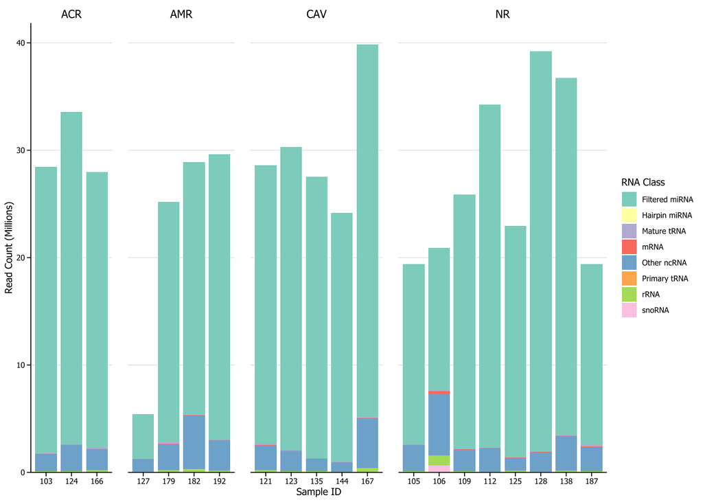

```r
library(showtext)
font_add("Tahoma", regular = "tahoma.ttf")
showtext_auto()

merged_df$Sample.name.s. <- gsub("_.*", "", merged_df$Sample.name.s.)
anno_long <- merged_df %>%
  pivot_longer(
    cols = -c(Sample.name.s., condition, antibody),
    names_to = "RNA_Class",
    values_to = "Count"
  )

rna_labels <- c(
  "Filtered.miRNA.Reads" = "Filtered miRNA",
  "Hairpin.miRNAs"       = "Hairpin miRNA",
  "mature.tRNA.Reads"    = "Mature tRNA",
  "mRNA.Reads"           = "mRNA",
  "ncRNA.others"         = "Other ncRNA",
  "primary.tRNA.Reads"   = "Primary tRNA",
  "rRNA.Reads"           = "rRNA",
  "snoRNA.Reads"         = "snoRNA"
)

plot_bars <- ggplot(anno_long, aes(x = as.character(Sample.name.s.), y = Count / 1000000, fill = RNA_Class)) +
  geom_col(width = 0.85) +
  facet_grid(~ condition, scales = "free_x", space = "free_x") +
  labs(x = "Sample ID", y = "Read Count (Millions)") +

  scale_fill_brewer(palette = "Set3", name = "RNA Class", labels = rna_labels) +
  scale_y_continuous(expand = expansion(mult = c(0, 0.05))) +
  theme_bw(base_family = "Tahoma", base_size = 7) +

  theme(
    text = element_text(family = "Tahoma"),
    strip.background = element_rect(fill = "white", color = "white", linewidth = 2),
    strip.text = element_text(face = "plain", size = 8, color = "black"),

    axis.line = element_line(color = "black", linewidth = 0.3),
    axis.ticks = element_line(color = "black", linewidth = 0.3),
    axis.ticks.length = unit(1, "mm"),
    axis.text = element_text(family = "Tahoma", color = "black"),
    panel.border = element_blank(),
    panel.grid.major.x = element_blank(),
    panel.grid.minor = element_blank(),
    panel.spacing = unit(4, "mm"),
    legend.key.size = unit(4, "mm")
  )

print(plot_bars)
```

```r
ggsave("./pictures_transpl/plot_distr.png", plot = plot_bars,
       width = 168, height = 110, units = "mm", dpi = 500, bg = "white")
```

**Additional calculations**  
Computing the total sum of reads for each sample

```r
cols <- names(anno) != "Sample.name.s."

anno["total", cols] <- colSums(anno[, cols], na.rm = TRUE)
anno["total", "Sample.name.s."] <- "total"
anno
```

```
##       Sample.name.s. Filtered.miRNA.Reads Hairpin.miRNAs mature.tRNA.Reads
## 1      105_S1_R1_001             16771254           1611             44435
## 2      166_S4_R1_001             25629332           1367            140585
## 3      144_S5_R1_001             23203639            530             38313
## 4      135_S7_R1_001             26188565           1172             35388
## 5      128_S8_R1_001             37265549           1304             44252
## 6      109_S9_R1_001             23665139            872             60970
## 7     187_S10_R1_001             16840522           1475            175725
## 8     125_S11_R1_001             21501577           2151             60585
## 9     124_S16_R1_001             30962515           1063             53091
## 10    103_S17_R1_001             26669389           1311             55217
## 11    123_S20_R1_001             28199537            787             74261
## 12    192_S22_R1_001             26591265           1336             69774
## 13    167_S23_R1_001             34709811           6782             83663
## 14    121_S24_R1_001             25977279            750             91450
```

[output cut: 29 more lines]

**Percentage Distribution of RNA Biotypes**  
Calculating the percentage of each small RNA class relative to the total number of reads in the entire experiment.

```r
total_vec <- anno["total", setdiff(names(anno), "Sample.name.s.")]
total_pct <- total_vec / sum(total_vec) * 100
total_pct
```

```
##       Filtered.miRNA.Reads Hairpin.miRNAs mature.tRNA.Reads primary.tRNA.Reads
## total             89.84285    0.005662447         0.2795017       0.0001954769
##       snoRNA.Reads rRNA.Reads ncRNA.others mRNA.Reads
## total    0.1622628  0.6687182     8.922031  0.1187772
```

**Sequencing Depth per Group**  
Aggregating the total number of reads for each clinical group (used to describe cohort characteristics in the manuscript text).

```r
summed_anno_plt <- summed_anno %>%
  pivot_longer(cols = -condition, names_to = "RNA_Type", values_to = "Count")

reads_before <- summed_anno_plt %>%
  group_by(condition) %>%
  summarise(total_reads = sum(Count))
reads_before
```

```
## # A tibble: 4 × 2
##   condition total_reads
##   <chr>           <int>
## 1 ACR          89999923
## 2 AMR          89214946
## 3 CAV         150451408
## 4 NR          218736197
```

## Differential Expression Analysis

**Custom Functions for DESeq2 Automation**  
Creating two custom functions:  
*run_deseq_pipeline* — sets the reference group, applies a low-count filter (minimum of 10 reads in at least 3 samples), and runs the DESeq2 model.  
*extract_and_plot* — extracts comparison results, applies apeglm shrinkage for LFC correction, filters significant miRNAs, and generates a Volcano Plot.

```r
run_deseq_pipeline <- function(counts_mat, metadata, design_formula, ref_level) {
  metadata$condition <- relevel(factor(metadata$condition), ref = ref_level)

  dds <- DESeqDataSetFromMatrix(
    countData = counts_mat,
    colData = metadata,
    design = design_formula
  )

  keep <- rowSums(counts(dds) >= 10) >= 3
  dds <- dds[keep, ]

  dds <- DESeq(dds, fitType = "parametric")

  return(dds)
}

extract_and_plot <- function(dds, target_coef, plot_title, save_path) {
  res <- results(dds, name = target_coef)
  resLFC <- lfcShrink(dds, coef = target_coef, type = "apeglm")

  res_sign <- as.data.frame(subset(res, padj < 0.05 & !is.na(padj) & abs(log2FoldChange) > 1))
  resLFC_sign <- as.data.frame(subset(resLFC, padj < 0.05 & !is.na(padj)))

  plt <- EnhancedVolcano(
    res,
    lab = rownames(res),
    x = 'log2FoldChange',
    y = 'padj',
    subtitle = NULL,
    caption = NULL,
    legendLabels = c('NS', 'Log2 FC', 'P-adjusted', 'P-adjusted and Log2 FC'),
    ylab = bquote(~-Log[10]~ 'P-adjusted'),
    pCutoff = 0.05,
    FCcutoff = 1.0,
    labSize = 3.0,
    boxedLabels = FALSE,
    col = c('black', '#CBD5E8', '#B3E2CD', "#FF6600"),
    colAlpha = 1,
    title = NULL,
    selectLab = rownames(res_sign),
    drawConnectors = TRUE,
    xlim = c(-10, 10),
    ylim = c(0, 5)
)

  plt <- plt +
    theme_bw(base_family = "Tahoma", base_size = 7)
  ggsave(save_path, plot = plt, width = 8, height = 6, dpi = 500, bg = "white")

  return(list(
    res_raw = res,
    res_shrunken = resLFC,
    sig_raw = res_sign,
    sig_shrunken = resLFC_sign,
    plot = plt
  ))
}
```

### Pairwise Comparisons with the Normal Reference (NR as Reference)

**Differential expression analysis for Antibody-Mediated Rejection (AMR vs NR), Figure 2A**

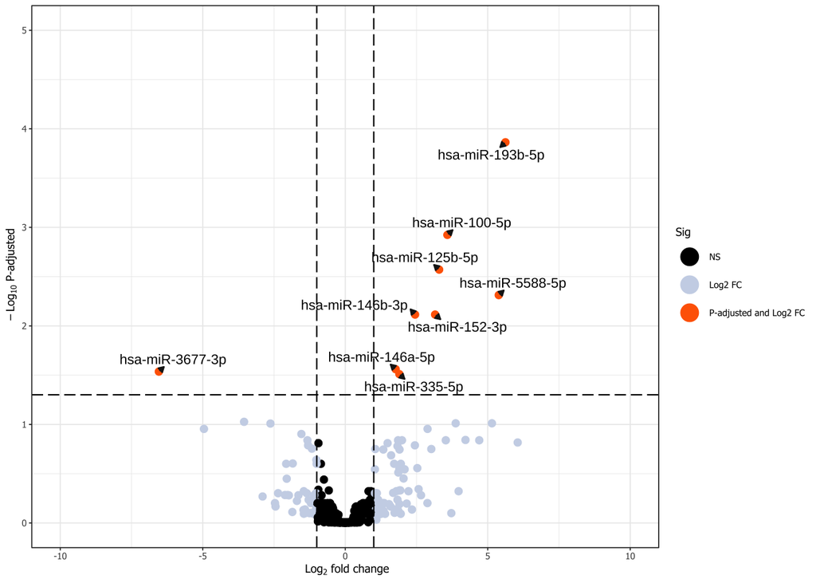

```r
dds_nr_ref <- run_deseq_pipeline(counts, coldata, ~ condition, "NR")

# AMR vs NR
res_AMR_vs_NR <- extract_and_plot(
  dds = dds_nr_ref,
  target_coef = "condition_AMR_vs_NR",
  plot_title = "AMR vs NR",
  save_path = "./pictures_transpl/transpl_VolcanoPlot_AMR_vs_NR.svg"
)
res_AMR_vs_NR$plot
```

```r
res_AMR_vs_NR$sig_raw
```

```
##                   baseMean log2FoldChange     lfcSE      stat       pvalue
## hsa-miR-100-5p  1474.78255       3.584092 0.7926169  4.521847 6.130244e-06
## hsa-miR-125b-5p  426.32541       3.294506 0.7738426  4.257333 2.068801e-05
## hsa-miR-146a-5p 5344.62711       1.769101 0.5078480  3.483525 4.948567e-04
## hsa-miR-146b-3p  300.36136       2.449628 0.6344974  3.860737 1.130453e-04
## hsa-miR-152-3p   290.86888       3.153140 0.8190839  3.849594 1.183137e-04
## hsa-miR-193b-5p  206.21404       5.621551 1.1037210  5.093272 3.519368e-07
## hsa-miR-335-5p   919.95668       1.899823 0.5614182  3.383971 7.144560e-04
## hsa-miR-3677-3p   16.05159      -6.541315 1.9057003 -3.432499 5.980458e-04
## hsa-miR-5588-5p   93.25007       5.386293 1.3281772  4.055402 5.004812e-05
##                         padj
## hsa-miR-100-5p  0.0011923325
## hsa-miR-125b-5p 0.0026825457
## hsa-miR-146a-5p 0.0274998952
## hsa-miR-146b-3p 0.0076706745
## hsa-miR-152-3p  0.0076706745
## hsa-miR-193b-5p 0.0001369034
## hsa-miR-335-5p  0.0308803753
## hsa-miR-3677-3p 0.0290799773
## hsa-miR-5588-5p 0.0048671795
```

```r
res_AMR_vs_NR$sig_shrunken
```

[output not shown]

**Per-sample normalized expression of the principal candidate miRNAs across clinical groups, Figure 3**

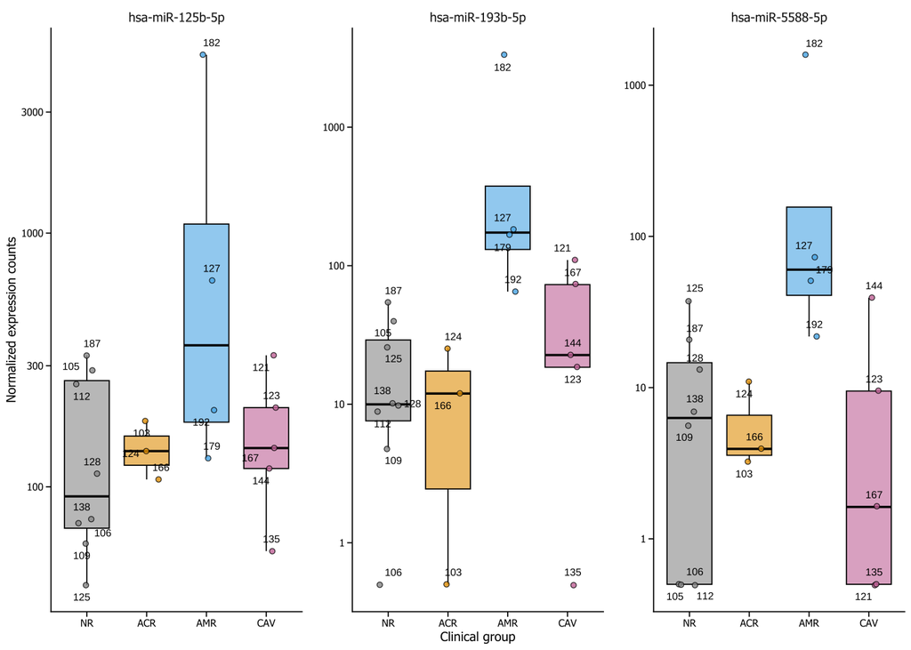

```r
target_mirnas <- c("hsa-miR-193b-5p", "hsa-miR-125b-5p", "hsa-miR-5588-5p")
all_counts <- data.frame()

for (mirna in target_mirnas) {
  count_data <- plotCounts(dds_nr_ref, gene=mirna, intgroup="condition", returnData=TRUE)
  count_data$sample <- gsub("_.*", "", rownames(count_data))
  count_data$miRNA <- mirna
  all_counts <- rbind(all_counts, count_data)
}

safe_colors <- c(ACR = "#E69F00", AMR = "#56B4E9", CAV = "#CC79A7", NR = "#999999")

plt <- ggplot(all_counts, aes(x=condition, y=count, fill=condition)) +
  geom_boxplot(alpha=0.6, outlier.shape = NA, color="black", linewidth=0.3) +

  geom_jitter(width=0.2, size=1.2, alpha=0.8, shape=21, color="black") +

  geom_text_repel(aes(label=sample), size=2, max.overlaps=15) +

  scale_y_log10() +
  scale_fill_manual(values = safe_colors) +
  facet_wrap(~ miRNA, scales="free_y", ncol=3) +

  labs(y = "Normalized expression counts", x = "Clinical group") +
  theme_classic(base_family = "Tahoma", base_size = 7) +

  theme(
    strip.text = element_text(size = 7, face = "bold.italic"),
    strip.background = element_rect(fill = NA, color = NA),
    legend.position = "none",

    axis.line = element_line(color = "black", linewidth = 0.3),
    axis.ticks = element_line(color = "black", linewidth = 0.3),
    axis.ticks.length = unit(1, "mm"),
    axis.text = element_text(color = "black"),
    panel.spacing = unit(4, "mm")
  )

print(plt)
```

```r
# Statistical graphs should have 300-500 dpi[cite: 1].
# Figures should be submitted in lossless PNG format[cite: 1].
ggsave("./pictures_transpl/126281-g003.png", plot = plt, width = 168, height = 75, units = "mm", dpi = 500)
ggsave("./pictures_transpl/126281-g003.svg", plot = plt, width = 168, height = 75, units = "mm")
```

**Differential expression analysis for Acute Cellular Rejection (ACR vs NR)**

```r
res_ACR_vs_NR <- extract_and_plot(
  dds = dds_nr_ref,
  target_coef = "condition_ACR_vs_NR",
  plot_title = "ACR vs NR",
  save_path = "./pictures_transpl/transpl_VolcanoPlot_ACR_vs_NR.svg"
)
res_ACR_vs_NR$sig_raw
```

```
## [1] baseMean       log2FoldChange lfcSE          stat           pvalue
## [6] padj
## <0 rows> (or 0-length row.names)
```

```r
res_ACR_vs_NR$sig_shrunken
```

```
## [1] baseMean       log2FoldChange lfcSE          pvalue         padj
## <0 rows> (or 0-length row.names)
```

**Differential expression analysis for Cardiac Allograft Vasculopathy (CAV vs NR).**

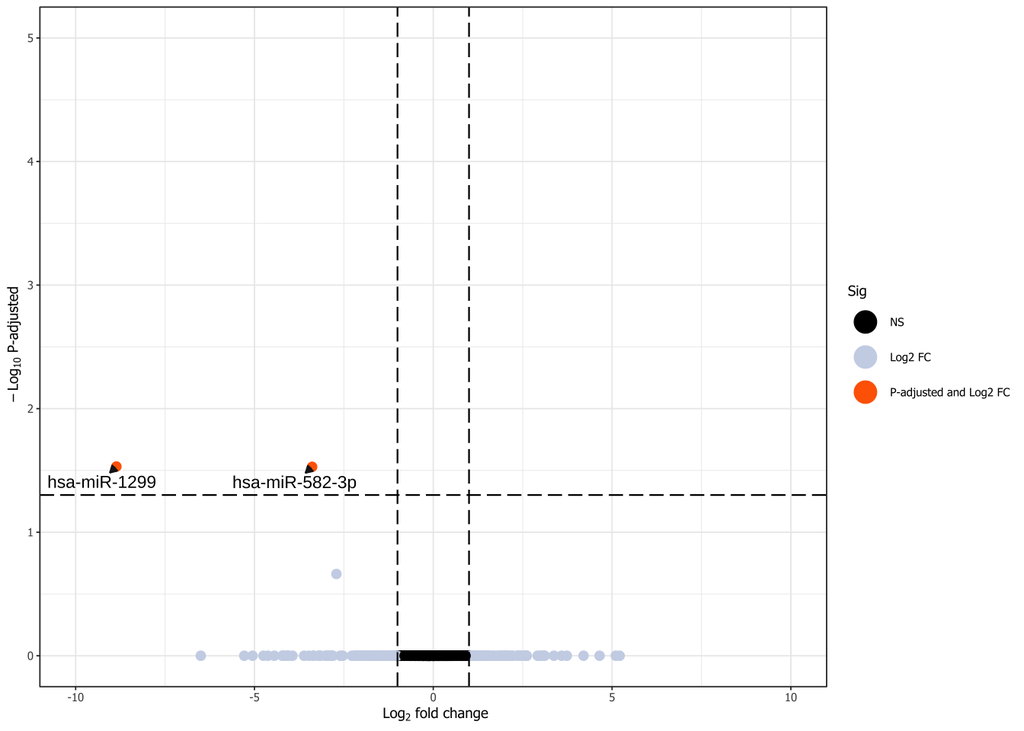

```r
res_CAV_vs_NR <- extract_and_plot(
  dds = dds_nr_ref,
  target_coef = "condition_CAV_vs_NR",
  plot_title = "CAV vs NR",
  save_path = "./pictures_transpl/transpl_VolcanoPlot_CAV_vs_NR.svg"
)
res_CAV_vs_NR$plot
```

```r
res_CAV_vs_NR$sig_raw
```

```
##                 baseMean log2FoldChange     lfcSE      stat       pvalue
## hsa-miR-1299     73.4441      -8.860890 2.1823401 -4.060270 4.901597e-05
## hsa-miR-582-3p 1406.6345      -3.387328 0.8698596 -3.894108 9.856060e-05
##                      padj
## hsa-miR-1299   0.02940958
## hsa-miR-582-3p 0.02956818
```

```r
res_CAV_vs_NR$sig_shrunken
```

```
##                 baseMean log2FoldChange       lfcSE       pvalue       padj
## hsa-miR-1299     73.4441  -6.169870e-07 0.001442695 4.901597e-05 0.02940958
## hsa-miR-582-3p 1406.6345  -2.754192e-06 0.001442696 9.856060e-05 0.02956818
```

### Comparisons Between Rejection Types (ACR as Reference)

**Changing the baseline to ACR to identify differences between rejection types (AMR vs ACR), Figure 2D**

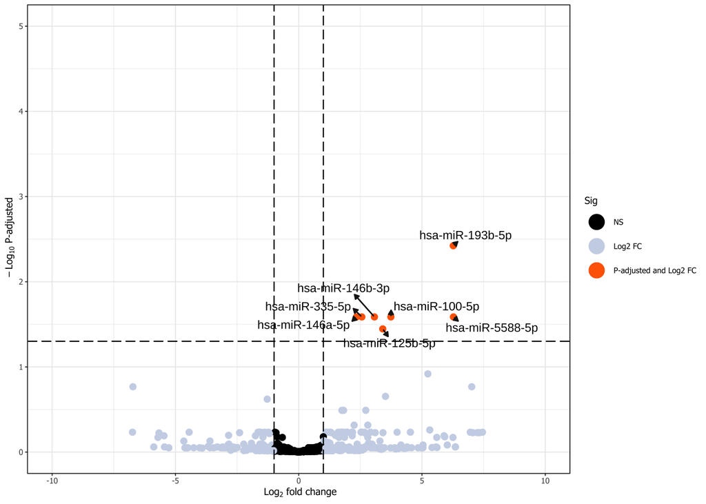

```r
dds_acr_ref <- run_deseq_pipeline(counts, coldata, ~ condition, "ACR")

res_AMR_vs_ACR <- extract_and_plot(
  dds = dds_acr_ref,
  target_coef = "condition_AMR_vs_ACR",
  plot_title = "AMR vs ACR",
  save_path = "./pictures_transpl/transpl_VolcanoPlot_AMR_vs_ACR.svg"
)
res_AMR_vs_ACR$plot
```

```r
res_AMR_vs_ACR$sig_raw
```

```
##                   baseMean log2FoldChange     lfcSE     stat       pvalue
## hsa-miR-100-5p  1474.78255       3.737566 0.9888560 3.779687 1.570259e-04
## hsa-miR-125b-5p  426.32541       3.408627 0.9659145 3.528911 4.172731e-04
## hsa-miR-146a-5p 5344.62711       2.342284 0.6335080 3.697323 2.178852e-04
## hsa-miR-146b-3p  300.36136       3.070913 0.7934626 3.870268 1.087157e-04
## hsa-miR-193b-5p  206.21404       6.269361 1.3881619 4.516304 6.292825e-06
## hsa-miR-335-5p   919.95668       2.560246 0.7007989 3.653324 2.588668e-04
## hsa-miR-5588-5p   93.25007       6.275151 1.6799270 3.735372 1.874382e-04
##                        padj
## hsa-miR-100-5p  0.025886683
## hsa-miR-125b-5p 0.035766270
## hsa-miR-146a-5p 0.025886683
## hsa-miR-146b-3p 0.025886683
## hsa-miR-193b-5p 0.003775695
## hsa-miR-335-5p  0.025886683
## hsa-miR-5588-5p 0.025886683
```

```r
res_AMR_vs_ACR$sig_shrunken
```

```
##                   baseMean log2FoldChange     lfcSE       pvalue        padj
## hsa-miR-100-5p  1474.78255       3.146908 1.1371650 1.570259e-04 0.025886683
## hsa-miR-125b-5p  426.32541       2.780741 1.1344895 4.172731e-04 0.035766270
## hsa-miR-146a-5p 5344.62711       2.002311 0.6902429 2.178852e-04 0.025886683
## hsa-miR-146b-3p  300.36136       2.630990 0.8821514 1.087157e-04 0.025886683
## hsa-miR-193b-5p  206.21404       5.567209 1.5702312 6.292825e-06 0.003775695
## hsa-miR-335-5p   919.95668       2.166141 0.7743876 2.588668e-04 0.025886683
## hsa-miR-5588-5p   93.25007       5.112907 2.1618903 1.874382e-04 0.025886683
```

**Changing the baseline to ACR to identify differences between rejection types (CAV vs ACR)**

```r
res_CAV_vs_ACR <- extract_and_plot(
  dds = dds_acr_ref,
  target_coef = "condition_CAV_vs_ACR",
  plot_title = "CAV vs ACR",
  save_path = "./pictures_transpl/transpl_VolcanoPlot_CAV_vs_ACR.svg"
)
res_CAV_vs_ACR$sig_raw
```

```
## [1] baseMean       log2FoldChange lfcSE          stat           pvalue
## [6] padj
## <0 rows> (or 0-length row.names)
```

```r
res_CAV_vs_ACR$sig_shrunken
```

```
## [1] baseMean       log2FoldChange lfcSE          pvalue         padj
## <0 rows> (or 0-length row.names)
```

### Pairwise Comparisons with CAV (CAV as Reference)

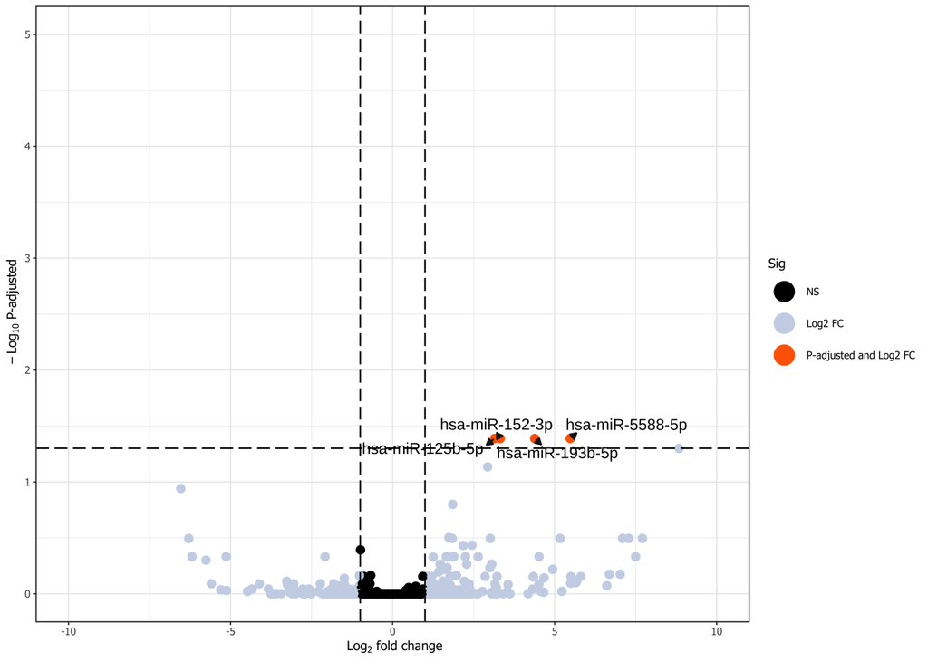

```r
dds_cav_ref <- run_deseq_pipeline(counts, coldata, ~ condition, "CAV")

res_AMR_vs_CAV <- extract_and_plot(
  dds = dds_cav_ref,
  target_coef = "condition_AMR_vs_CAV",
  plot_title = "AMR vs CAV",
  save_path = "./pictures_transpl/transpl_VolcanoPlot_AMR_vs_CAV.svg"
)
res_AMR_vs_CAV$plot
```

```r
res_AMR_vs_CAV$sig_raw
```

```
##                  baseMean log2FoldChange     lfcSE     stat       pvalue
## hsa-miR-125b-5p 426.32541       3.148576 0.8474899 3.715179 0.0002030599
## hsa-miR-152-3p  290.86888       3.319357 0.8973780 3.698950 0.0002164928
## hsa-miR-193b-5p 206.21404       4.383945 1.2043621 3.640056 0.0002725788
## hsa-miR-5588-5p  93.25007       5.481253 1.4556632 3.765468 0.0001662373
##                       padj
## hsa-miR-125b-5p 0.04088682
## hsa-miR-152-3p  0.04088682
## hsa-miR-193b-5p 0.04088682
## hsa-miR-5588-5p 0.04088682
```

```r
res_AMR_vs_CAV$sig_shrunken
```

```
##                  baseMean log2FoldChange     lfcSE       pvalue       padj
## hsa-miR-125b-5p 426.32541       2.658047 0.9177471 0.0002030599 0.04088682
## hsa-miR-152-3p  290.86888       2.793943 0.9760412 0.0002164928 0.04088682
## hsa-miR-193b-5p 206.21404       3.643651 1.3391342 0.0002725788 0.04088682
## hsa-miR-5588-5p  93.25007       4.592788 1.6323084 0.0001662373 0.04088682
```

**Changing the baseline to CAV to evaluate ACR vs CAV**

```r
res_ACR_vs_CAV <- extract_and_plot(
  dds = dds_cav_ref,
  target_coef = "condition_ACR_vs_CAV",
  plot_title = "ACR vs CAV",
  save_path = "./pictures_transpl/transpl_VolcanoPlot_ACR_vs_CAV.svg"
)
res_ACR_vs_CAV$sig_raw
```

```
## [1] baseMean       log2FoldChange lfcSE          stat           pvalue
## [6] padj
## <0 rows> (or 0-length row.names)
```

```r
res_ACR_vs_CAV$sig_shrunken
```

```
## [1] baseMean       log2FoldChange lfcSE          pvalue         padj
## <0 rows> (or 0-length row.names)
```

### Covariate-Adjusted Model

**Adding antibody status (antibody) to the model design (~ antibody + condition) to account for the potential confounding effect of HLA sensitization on the expression profile, Figure 2C**

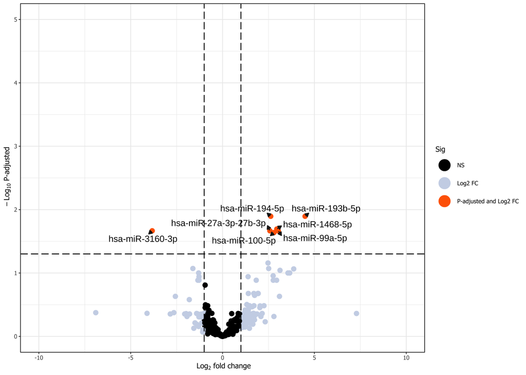

```r
dds_covariates <- run_deseq_pipeline(counts, coldata, ~ antibody + condition, "NR")

res_AMR_vs_NR_adj <- extract_and_plot(
  dds = dds_covariates,
  target_coef = "condition_AMR_vs_NR",
  plot_title = "AMR vs NR (Adjusted for HLA)",
  save_path = "./pictures_transpl/transpl_VolcanoPlot_AMR_vs_NR_adjusted.svg"
)
res_AMR_vs_NR_adj$plot
```

```r
res_AMR_vs_NR_adj$sig_raw
```

```
##                          baseMean log2FoldChange     lfcSE      stat
## hsa-miR-100-5p          1474.7826       2.801127 0.8008312  3.497775
## hsa-miR-1468-5p          367.5035       2.952707 0.7874372  3.749769
## hsa-miR-193b-5p          206.2140       4.492812 1.1096927  4.048699
## hsa-miR-194-5p           990.5922       2.622212 0.6618091  3.962188
## hsa-miR-27a-3p-27b-3p 223176.1189       2.576278 0.7245867  3.555514
## hsa-miR-3160-3p          109.4773      -3.830073 1.0508785 -3.644640
## hsa-miR-99a-5p           678.0566       3.031757 0.8514398  3.560741
##                             pvalue       padj
## hsa-miR-100-5p        4.691566e-04 0.02298867
## hsa-miR-1468-5p       1.769976e-04 0.02023672
## hsa-miR-193b-5p       5.150309e-05 0.01273665
## hsa-miR-194-5p        7.426616e-05 0.01273665
## hsa-miR-27a-3p-27b-3p 3.772406e-04 0.02156559
## hsa-miR-3160-3p       2.677667e-04 0.02156559
## hsa-miR-99a-5p        3.698093e-04 0.02156559
```

```r
res_AMR_vs_NR_adj$sig_shrunken
```

```
##                          baseMean log2FoldChange     lfcSE       pvalue
## hsa-miR-100-5p          1474.7826      0.3213212 0.5522507 4.691566e-04
## hsa-miR-1468-5p          367.5035      0.4140750 0.6685373 1.769976e-04
## hsa-miR-193b-5p          206.2140      2.8972054 1.9047628 5.150309e-05
## hsa-miR-194-5p           990.5922      1.6267753 1.2094640 7.426616e-05
## hsa-miR-27a-3p-27b-3p 223176.1189      1.7979669 1.4918357 3.772406e-04
## hsa-miR-3160-3p          109.4773     -3.1062172 1.2911761 2.677667e-04
## hsa-miR-99a-5p           678.0566      0.4250333 0.6933178 3.698093e-04
##                             padj
## hsa-miR-100-5p        0.02298867
## hsa-miR-1468-5p       0.02023672
## hsa-miR-193b-5p       0.01273665
## hsa-miR-194-5p        0.01273665
## hsa-miR-27a-3p-27b-3p 0.02156559
## hsa-miR-3160-3p       0.02156559
## hsa-miR-99a-5p        0.02156559
```

## Venn Diagram

**Venn diagram showing the overlap of filtered miRNAs among the clinical groups, Figure 1D**  
Applying a global noise filter to the raw counts and identifying the lists of miRNAs confidently expressed in each clinical group to build an intersection diagram

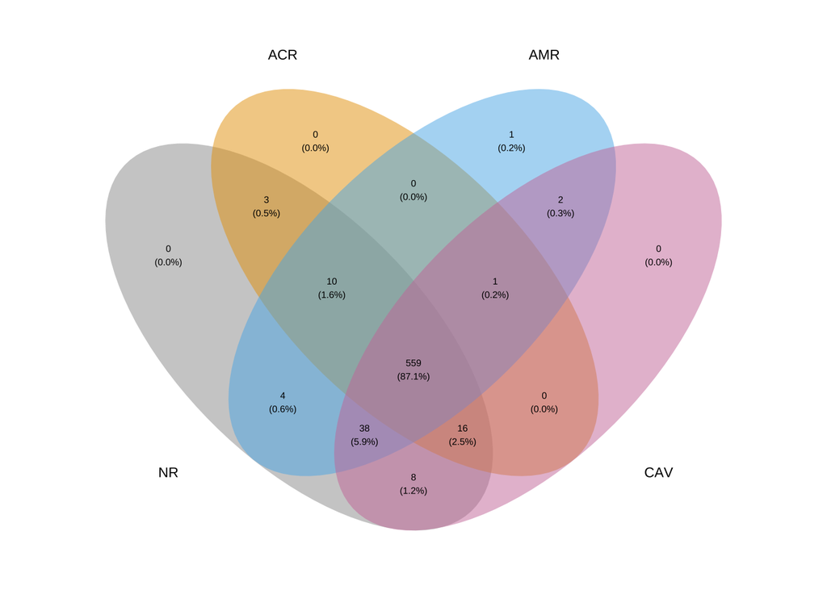

```r
keep_global <- rowSums(counts >= 10) >= 3
filtered_counts <- counts[keep_global, ]

counts_mat <- filtered_counts

get_filtered_mirnas <- function(condition_name){
    samps <- coldata %>%
        filter(condition == condition_name) %>%
        pull(sample)
    valid_samps <- intersect(samps, colnames(counts_mat))
    sub_counts <- counts_mat[, valid_samps, drop = FALSE]
    keep_group <- rowSums(sub_counts > 0) > 0
    rownames(sub_counts)[keep_group]
}

venn_list <- list(
  NR  = get_filtered_mirnas("NR"),
  ACR = get_filtered_mirnas("ACR"),
  AMR = get_filtered_mirnas("AMR"),
  CAV = get_filtered_mirnas("CAV")
)

plot_venn <- ggvenn(
  venn_list,
  fill_color = c("#999999", "#E69F00", "#56B4E9", "#CC79A7"),
  fill_alpha = 0.5,
  stroke_size = 0,

  set_name_size = 3,
  text_size = 2
)

plot_venn <- plot_venn +
  theme_void(base_family = "Tahoma")

print(plot_venn)
```

```r
ggsave("./pictures_transpl/venna_plot.svg", plot = plot_venn, width = 8, height = 6, dpi = 500, bg = "white")
```

## Unsupervised Clustering & PCA

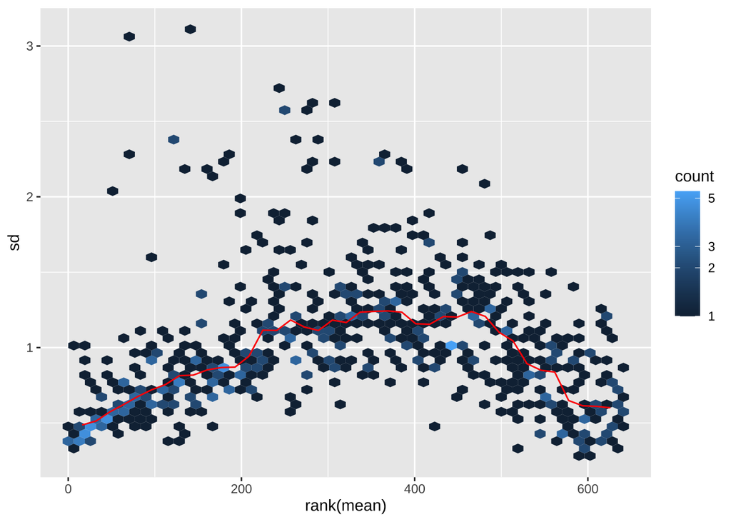

```r
rlt <- rlog(dds_nr_ref)
meanSdPlot(assay(rlt))
```

## Principal Component Analysis ##  
**Principal component analysis (PCA) of filtered miRNA expression profiles according to clinical group and the presence of contemporaneous anti-HLAs, Figure 1B**  
Generating a PCA plot to evaluate the global segregation of samples in a 2D space based on their expression profiles. Colors encode the clinical group, and shapes represent the antibody status

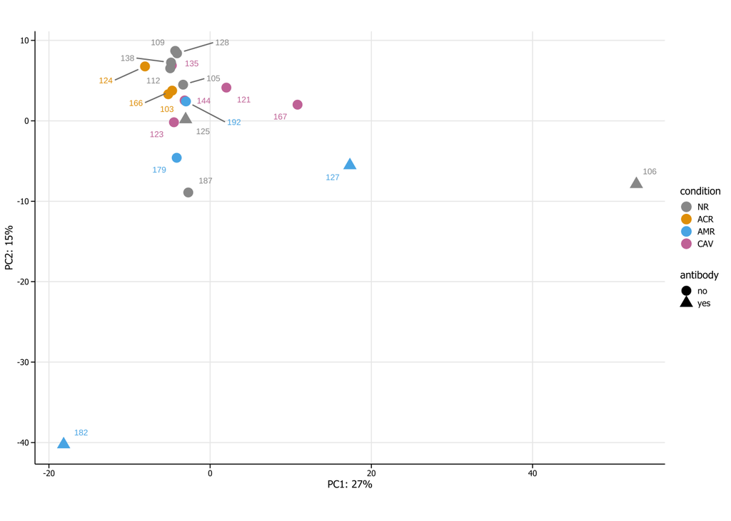

```r
pcaData <- plotPCA(rlt, intgroup=c("condition", "antibody"), returnData = TRUE)
percentVar <- round(100 * attr(pcaData, "percentVar"))

pcaData$sample <- gsub("_.*", "", rownames(pcaData))

custom_palette <- c(ACR = "#E69F00", AMR = "#56B4E9", CAV = "#CC79A7", NR = "#999999")

plot_pca <- ggplot(pcaData, aes(PC1, PC2, color = condition, shape = antibody)) +
  geom_point(size = 3) +
  geom_text_repel(
    aes(label = sample),
    size = 2,
    box.padding = 0.4,
    point.padding = 0.3,
    segment.color = "grey50",
    segment.size = 0.4,
    max.overlaps = Inf
  ) +
  xlab(paste0("PC1: ", percentVar[1], "%")) +
  ylab(paste0("PC2: ", percentVar[2], "%")) +
  coord_fixed() +

  theme_bw(base_family = "Tahoma", base_size = 7) +
  scale_color_manual(values = custom_palette) +


  theme(
    axis.line = element_line(color = "black", linewidth = 0.3),
    axis.ticks = element_line(color = "black", linewidth = 0.3),
    axis.ticks.length = unit(1, "mm"),
    axis.text = element_text(color = "black"),

    legend.key.size = unit(3, "mm"),
    legend.title = element_text(size = 7, face = "bold"),
    legend.text = element_text(size = 6),

    panel.border = element_blank(),
    panel.grid.minor = element_blank()
  )

plot_pca
```

```r
ggsave("./pictures_transpl/transpl_PCA_plot.svg", plot = plot_pca, width = 8, height = 6, dpi = 500, bg = "white")
```

## Sample Distance Heatmap

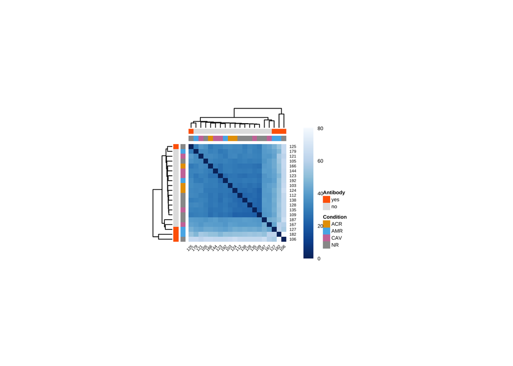

```r
#Calculate distances and convert to matrix
sampleDists <- dist(t(assay(rlt)))
sampleDistMatrix <- as.matrix(sampleDists)

rownames(sampleDistMatrix) <- gsub("_.*", "", colnames(rlt))
colnames(sampleDistMatrix) <- gsub("_.*", "", colnames(rlt))

# Extracting the columns you mentioned using in plotPCA
anno_df <- as.data.frame(colData(rlt)[, c("condition", "antibody")])

# Capitalize the column names so the legends appear as "Condition" and "Antibody"
colnames(anno_df) <- c("Condition", "Antibody")

# Define custom colors for your annotations to match the image
anno_colors <- list(
  Condition =  c(ACR = "#E69F00", AMR = "#56B4E9", CAV = "#CC79A7", NR = "#999999"),
  Antibody = c(yes = "#FF6600", no = "#E2E2E2")
)
colors <- colorRampPalette(rev(brewer.pal(9, "Blues")))(255)

plot_hm <- pheatmap(
  sampleDistMatrix,
  clustering_distance_rows = "euclidean",
  clustering_distance_cols = "euclidean",
  color = colors,
  annotation_col = anno_df,
  annotation_row = anno_df,
  annotation_colors = anno_colors,
  annotation_names_row = FALSE,
  annotation_names_col = FALSE,
  fontsize = 5,
  fontsize_row = 4,
  fontsize_col = 4,
  angle_col = "45",
  treeheight_row = 15,
  treeheight_col = 15,
  border_color = NA,
  cellwidth = 4.8,
  cellheight = 4.8
)
```

```r
ggsave("./pictures_transpl/transpl_distance_heatmap.svg", plot = plot_hm, width = 9, height = 6, dpi = 500, bg = "white")
```

## Likelihood Ratio Test

Multi-Group Analysis (LRT). Performing a Likelihood Ratio Test comparing the full model (~ condition) against an intercept-only reduced model (~ 1) to identify miRNAs whose expression significantly changes in at least one group compared to all others.

```r
dds_lrt <- DESeq(dds_nr_ref, test = "LRT", reduced = ~ 1)

res_all <- results(dds_lrt, alpha = 0.05)
summary(res_all)
```

```
##
## out of 642 with nonzero total read count
## adjusted p-value < 0.05
## LFC > 0 (up)       : 6, 0.93%
## LFC < 0 (down)     : 2, 0.31%
## outliers [1]       : 42, 6.5%
## low counts [2]     : 0, 0%
## (mean count < 1)
## [1] see 'cooksCutoff' argument of ?results
## [2] see 'independentFiltering' argument of ?results
```

```r
res_all_sign <- as.data.frame(subset(res_all, padj < 0.05 & !is.na(padj)))
res_all_sign
```

```
##                   baseMean log2FoldChange     lfcSE     stat       pvalue
## hsa-miR-100-5p  1474.78255      0.6529607 0.7382176 30.21688 1.242431e-06
## hsa-miR-125b-5p  426.32541      0.1459306 0.7217727 28.76208 2.512614e-06
## hsa-miR-146a-5p 5344.62711      1.2443816 0.4727782 20.86453 1.123207e-04
## hsa-miR-146b-3p  300.36136      0.6102375 0.5915437 23.08622 3.874595e-05
## hsa-miR-152-3p   290.86888     -0.1662154 0.7647217 23.46497 3.230319e-05
## hsa-miR-193b-5p  206.21404      1.2376087 1.0321941 37.78878 3.133000e-08
## hsa-miR-335-5p   919.95668      0.1625046 0.5229418 19.46120 2.194745e-04
## hsa-miR-5588-5p   93.25007     -0.0949621 1.2526746 27.91035 3.792859e-06
##                         padj
## hsa-miR-100-5p  0.0003727294
## hsa-miR-125b-5p 0.0005025227
## hsa-miR-146a-5p 0.0096274859
## hsa-miR-146b-3p 0.0038745954
## hsa-miR-152-3p  0.0038745954
## hsa-miR-193b-5p 0.0000187980
## hsa-miR-335-5p  0.0164605857
## hsa-miR-5588-5p 0.0005689289
```

**Combined Figure 1**

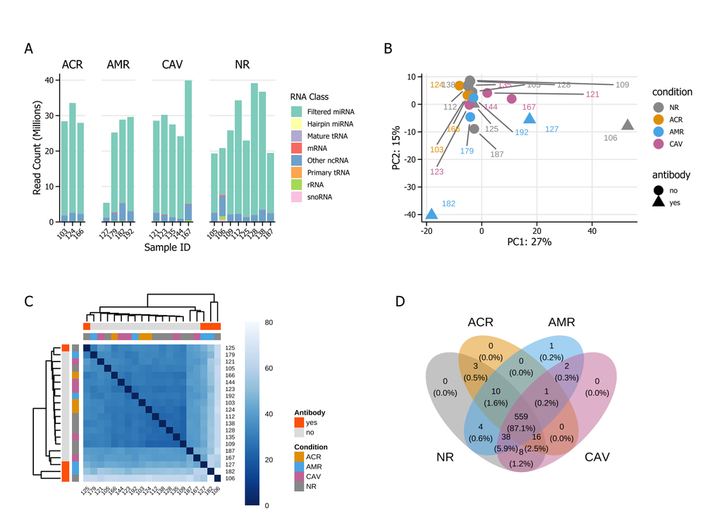

```r
plot_bars <- plot_bars +
  theme(
    axis.text.x = element_text(angle = 45, hjust = 1, size = 5),
    legend.key.size = unit(3, "mm"),
    legend.text = element_text(size = 5),
    legend.title = element_text(size = 6, face = "bold")
  )

plot_pca <- plot_pca +
  theme(
    legend.key.size = unit(3, "mm"),
    legend.text = element_text(size = 5)
  )

plot_hm <- as.ggplot(plot_hm)

combined_figure <- (plot_bars | plot_pca) /
                   (plot_hm | plot_venn)

final_figure <- combined_figure +
  plot_annotation(tag_levels = 'A') &
  theme(
    plot.tag = element_text(family = "Tahoma", face = "bold", size = 10),
    plot.margin = margin(3, 3, 3, 3, "mm")
  )

ggsave(
  "./pictures_transpl/126281-g001.svg",
  plot = final_figure,
  width = 168,
  height = 120,
  units = "mm",
  bg = "white"
)

ggsave(
  "./pictures_transpl/126281-g001.png",
  plot = final_figure,
  width = 168,
  height = 120,
  units = "mm",
  dpi = 600,
  bg = "white"
)
final_figure
```

**Combined Figure 2**

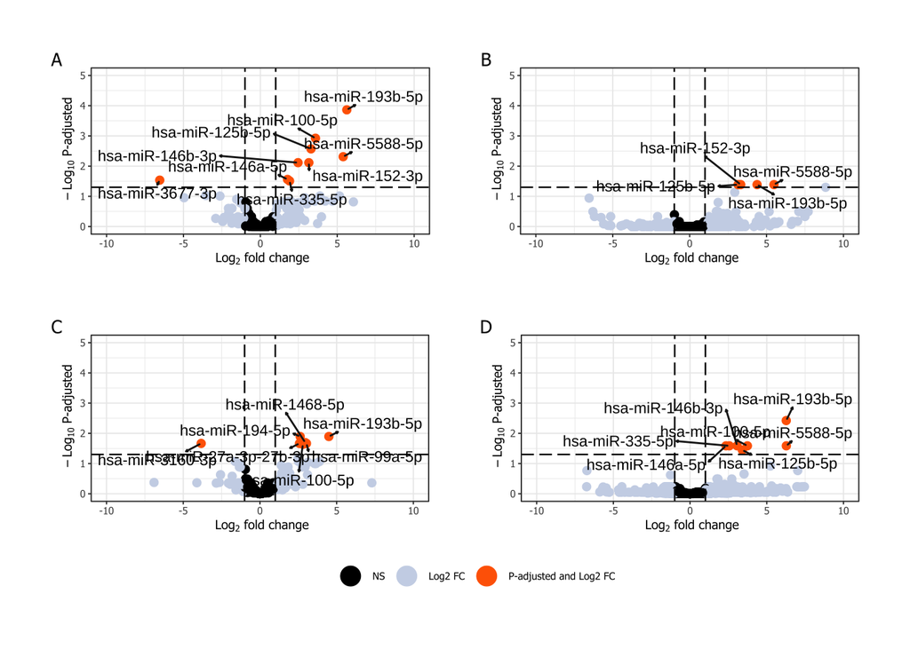

```r
combined_figure <- (res_AMR_vs_NR$plot | res_AMR_vs_CAV$plot) /
                   (res_AMR_vs_NR_adj$plot | res_AMR_vs_ACR$plot) +

  plot_layout(guides = "collect") +
  plot_annotation(tag_levels = 'A') &

  theme(
    legend.position = "bottom",
    legend.title = element_blank(),
    plot.tag = element_text(family = "Tahoma", face = "bold", size = 10),
    plot.margin = margin(5, 5, 5, 5, "mm")
  )

ggsave(
  "./pictures_transpl/126281-g002.png",
  plot = combined_figure,
  width = 168,
  height = 200,
  units = "mm",
  dpi = 600,
  bg = "white"
)
ggsave(
  "./pictures_transpl/126281-g002.svg",
  plot = combined_figure,
  width = 168,
  height = 200,
  units = "mm",
  dpi = 600,
  bg = "white"
)
combined_figure
```